# Joe Biden - Análisis exploratorio

Martín Pons

4/6/2020

```r
# librerias
library(qdapRegex)
library(sentimentr)
library(syuzhet)
library(lubridate)
library(tidyverse)
library(tidytext)
library(forcats)
library(tokenizers)
library(widyr)
library(igraph)
library(ggraph)
library(topicmodels)
library(forcats)
library(scales)
library(stringr)
library(extrafont)
library(reldist)
library(grid)
library(gridExtra)
library(boot)
library(ggradar)
library(tidygraph)
library(boot)
library(sp)
library(spData)
library(ggmap)
library(rgdal)
library(rgeos)
library(tmap)


# Sys.getenv()
Sys.setenv(JAVA_HOME = "C:\\Program Files\\Java\\jre1.8.0_251")

library(tm)
library(qdap)

# funciones auxiliares
source(here::here("scripts", "funciones_auxiliares.R"))

# paleta
plots_palette <- c("#ad5d51", "grey55", "#2b559e", "#947240")

# orden comunidades
comunidad_order <- c("GOP", "Independent", "DNC", "Progressives")
```

Estos datos han sido previamente procesados, sobre todo en lo que se refiere al texto de los tweets. Se excluyen términos relacionados con la pandemia que provoca la enfermedad COVID-19 (en el texto sin limpiar, hay un número amplio de términos para referirse a la enfermedad. Se han unificado todos en el término COVID19).

Se ha recogido también información sobre los seguidores de cuentas para definir 4 comunidades

- GOP: Seguidores de la cuenta del partido republicano, que no siguen la cuenta del partido demócrata ni del movimiento progresista
- DNS: Seguidores de la cuenta del partido demócrata, que no siguen la cuenta del partido republicano ni del movimiento progresista
- Progressives: Seguidores de la cuenta del movimiento progresista, que no siguen la cuenta del partido republicano ni del partido demócrata
- Independent: usuarios de tweets recogidos que no se encuentran incluidos en ninguno de los casos anteriores

```r
biden1 <- readRDS(here::here("datos_procesados", "formated_text_df_data", "biden_no_sent_part1.rds")) %>%
  filter(str_detect(text, "#?covid19|#?COVID|#?[Pp]andemic|#trumpvirus", negate = T)) %>%
  mutate(comunidad = fct_relevel(comunidad, c("GOP", "Independent", "DNC", "Progressives")),
         user_id = as.character(user_id))

biden2 <- readRDS(here::here("datos_procesados", "formated_text_df_data", "biden_no_sent_part2.rds")) %>%
  filter(str_detect(text, "#?covid19|#?COVID|#?[Pp]andemic|#trumpvirus", negate = T)) %>%
  mutate(comunidad = fct_relevel(comunidad, c("GOP", "Independent", "DNC", "Progressives")),
         user_id = as.character(user_id))

biden <- bind_rows(biden1, biden2) %>%
  distinct(status_id, .keep_all = T)

rm(biden1, biden2)
gc()
```

```
##            used  (Mb) gc trigger  (Mb) max used  (Mb)
## Ncells  5160515 275.7    9658325 515.9  5177089 276.5
## Vcells 32200147 245.7   52265405 398.8 50463096 385.1
```

## Distribucion de tweets

```r
library(tidyverse)
library(scales)
library(reldist)
library(qdapRegex)
library(sentimentr)
library(syuzhet)
library(lubridate)
library(tidyverse)
library(tidytext)
library(forcats)
library(tokenizers)
library(widyr)
library(igraph)
library(ggraph)
library(topicmodels)
library(forcats)
library(scales)
library(stringr)
library(extrafont)
library(reldist)
library(grid)
library(gridExtra)
library(boot)
library(ggradar)
library(tidygraph)
library(boot)
library(sp)
library(spData)
library(ggmap)
library(rgdal)
library(rgeos)
library(tmap)



biden %>%
  count(comunidad) %>%
  mutate(f = percent(n/sum(n), accuracy = 0.1))
```

```
## # A tibble: 4 x 3
##   comunidad         n f
##   <fct>         <int> <chr>
## 1 GOP          127833 18.9%
## 2 Independent  417877 61.8%
## 3 DNC           76078 11.2%
## 4 Progressives  54886 8.1%
```

```r
freq_tweets_usuario <- get_tweet_distribution(biden)

freq_tweets_usuario %>%
  arrange(desc(tweets)) %>%
  mutate(tweets_acum = cumsum(tweets),
         usuarios_acum = cumsum(usuarios)) %>%
  mutate(por_tweets_acum = tweets_acum / sum(tweets),
         por_usuarios_acum = usuarios_acum / sum(usuarios)) %>%
  mutate(int_users_acum = cut(por_usuarios_acum, breaks = seq(0, 1, by = 0.05))) %>%
  group_by(comunidad, int_users_acum) %>%
  summarise(porc_tweets = sum(porc_tweets)) %>%
  mutate(porc_tweets_acum = cumsum(porc_tweets))
```

```
## # A tibble: 33 x 4
## # Groups:   comunidad [4]
##    comunidad   int_users_acum porc_tweets porc_tweets_acum
##    <fct>       <fct>                <dbl>            <dbl>
##  1 GOP         (0,0.05]          0.985               0.985
##  2 GOP         (0.05,0.1]        0.00913             0.994
##  3 GOP         (0.1,0.15]        0.00249             0.997
##  4 GOP         (0.15,0.2]        0.000996            0.998
##  5 GOP         (0.2,0.25]        0.000830            0.998
##  6 GOP         (0.25,0.3]        0.000664            0.999
##  7 GOP         (0.35,0.4]        0.000498            1.00
##  8 GOP         (0.55,0.6]        0.000332            1.00
##  9 GOP         (0.95,1]          0.000166            1
## 10 Independent (0,0.05]          0.997               0.997
## # ... with 23 more rows
```

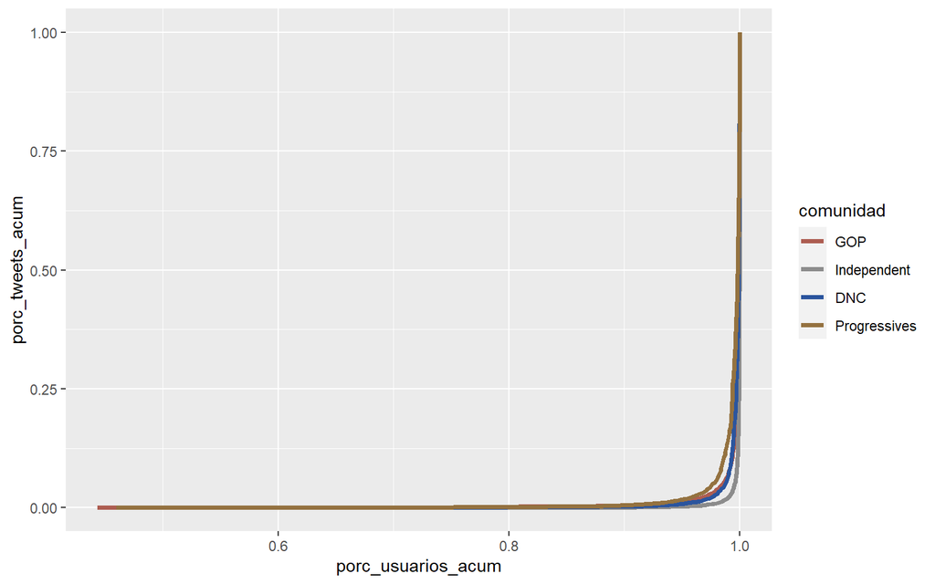

```r
# Curva de lorenz
freq_tweets_usuario %>%
  ggplot(aes(x = porc_usuarios_acum, y = porc_tweets_acum)) +
  geom_line(aes(color = comunidad), size = 1.3) +
  scale_color_manual(values = plots_palette)
```

```r
# gini
gini_comunidades <- freq_tweets_usuario %>%
  group_by(comunidad) %>%
  summarise(gini = gini(x = tweets, weights = porc_usuarios)) %>%
  arrange(desc(gini))
```

## Analisis de Topic

### Hashtags más usados

```r
biden <- biden %>%
  filter(comunidad != "Independent")


# datos tidy
biden_unigram <- get_unigrams(biden, c("#biden", "biden", "#joe", "joe"))
biden_hashtag <- get_hashtags(biden_unigram)
biden_frequency <- get_frequencies(biden_hashtag)


## Topics con networks ##

gop_biden_net <- create_hashtag_graph(biden_hashtag, "GOP", c("#biden", "#joe", "#joebiden", "joebiden"), minim_n = 3, nodos_n = 20)
```

```
## Iniciacion data frame de links
## Obtencion de data frame con conteo de hashtag  por status_id
## Obtencion de data frame de frequencias de hasthags
## Obtencion del porcentade de usuarios del hashtag
## Filtro de datos por nodos mas frecuentes
## Obtencion de tweets unicos
## Inicio de loop para obtener data frame de links
## [1] "Nodo: 1  -  #obamagate"
## [1] "Nodo: 2  -  #metoo"
## [1] "Nodo: 3  -  #tarareade"
## [1] "Nodo: 4  -  #trump2020"
## [1] "Nodo: 5  -  #youaintblack"
## [1] "Nodo: 6  -  #maga"
## [1] "Nodo: 7  -  #creepyjoe"
## [1] "Nodo: 8  -  #metoounlessitsbiden"
## [1] "Nodo: 9  -  #kag"
## [1] "Nodo: 10  -  #ibelievetarareade"
## [1] "Nodo: 11  -  #sleepyjoe"
## [1] "Nodo: 12  -  #believeallwomen"
## [1] "Nodo: 13  -  #fakenews"
## [1] "Nodo: 14  -  #kag2020"
## [1] "Nodo: 15  -  #biden2020"
## [1] "Nodo: 16  -  #democrats"
## [1] "Nodo: 17  -  #trump2020landslide"
## [1] "Nodo: 18  -  #dementiajoe"
## [1] "Nodo: 19  -  #maga2020"
## [1] "Nodo: 20  -  #foxnews"
## Fin de loop
## Adicion de nodos sin links
## Wrangling final del data frame
## Devolucion del data frame
```

```r
dnc_biden_net <- create_hashtag_graph(biden_hashtag, "DNC",  c("#biden", "#joe", "#joebiden", "joebiden"), minim_n = 3, nodos_n = 20)
```

```
## Iniciacion data frame de links
## Obtencion de data frame con conteo de hashtag  por status_id
## Obtencion de data frame de frequencias de hasthags
## Obtencion del porcentade de usuarios del hashtag
## Filtro de datos por nodos mas frecuentes
## Obtencion de tweets unicos
## Inicio de loop para obtener data frame de links
## [1] "Nodo: 1  -  #biden2020"
## [1] "Nodo: 2  -  #teamjoe"
## [1] "Nodo: 3  -  #trump"
## [1] "Nodo: 4  -  #tarareade"
## [1] "Nodo: 5  -  #gojoe"
## [1] "Nodo: 6  -  #joe2020"
## [1] "Nodo: 7  -  #metoo"
## [1] "Nodo: 8  -  #ibelievebiden"
## [1] "Nodo: 9  -  #ridenwithbiden"
## [1] "Nodo: 10  -  #ibelievejoe"
## [1] "Nodo: 11  -  #vote"
## [1] "Nodo: 12  -  #votebluetosaveamerica"
## [1] "Nodo: 13  -  #wethepeople"
## [1] "Nodo: 14  -  #voteblue2020"
## [1] "Nodo: 15  -  #votebiden2020"
## [1] "Nodo: 16  -  #resist"
## [1] "Nodo: 17  -  #america"
## [1] "Nodo: 18  -  #ridinwithbiden"
## [1] "Nodo: 19  -  #votebluetoendthisnightmare"
## [1] "Nodo: 20  -  #bidenharris2020"
## Fin de loop
## Adicion de nodos sin links
## Wrangling final del data frame
## Devolucion del data frame
```

```r
prg_biden_net <- create_hashtag_graph(biden_hashtag, "Progressives",  c("#biden", "#joe", "#joebiden", "joebiden"), minim_n = 3, nodos_n = 20)
```

```
## Iniciacion data frame de links
## Obtencion de data frame con conteo de hashtag  por status_id
## Obtencion de data frame de frequencias de hasthags
## Obtencion del porcentade de usuarios del hashtag
## Filtro de datos por nodos mas frecuentes
## Obtencion de tweets unicos
## Inicio de loop para obtener data frame de links
## [1] "Nodo: 1  -  #dropoutbiden"
## [1] "Nodo: 2  -  #metoo"
## [1] "Nodo: 3  -  #medicareforall"
## [1] "Nodo: 4  -  #ibelievetarareade"
## [1] "Nodo: 5  -  #neverbiden"
## [1] "Nodo: 6  -  #replacebiden"
## [1] "Nodo: 7  -  #joemustgo"
## [1] "Nodo: 8  -  #tarareade"
## [1] "Nodo: 9  -  #biden2020"
## [1] "Nodo: 10  -  #dropoutjoe"
## [1] "Nodo: 11  -  #ibelievebiden"
## [1] "Nodo: 12  -  #bluemaga"
## [1] "Nodo: 13  -  #demexit"
## [1] "Nodo: 14  -  #neverbidennevertrump"
## [1] "Nodo: 15  -  #timesupbiden"
## [1] "Nodo: 16  -  #bernieunsuspend"
## [1] "Nodo: 17  -  #bernie"
## [1] "Nodo: 18  -  #berniecomeback"
## [1] "Nodo: 19  -  #believewomen"
## [1] "Nodo: 20  -  #ibelievetara"
## Fin de loop
## Adicion de nodos sin links
## Wrangling final del data frame
## Devolucion del data frame
```

```r
biden_graph <- bind_graphs(gop_biden_net, dnc_biden_net, prg_biden_net) %>%
  activate(nodes) %>%
  mutate(comunidad = fct_relevel(comunidad, c("GOP", "DNC", "Progressives"))) %>%
  activate(edges) %>%
  filter(strength > 3) %>%
  activate(nodes) %>%
  mutate(degree = centrality_degree())
```

Los hashtags ya una clara diferencia y una clara polarización en base a los tópicos principales elegidos para la conversación: en el partido demócrata, casi todos son tópicos positivos relacionados con Biden. En el movimiento progresista, casi todos son tópicos negativos.

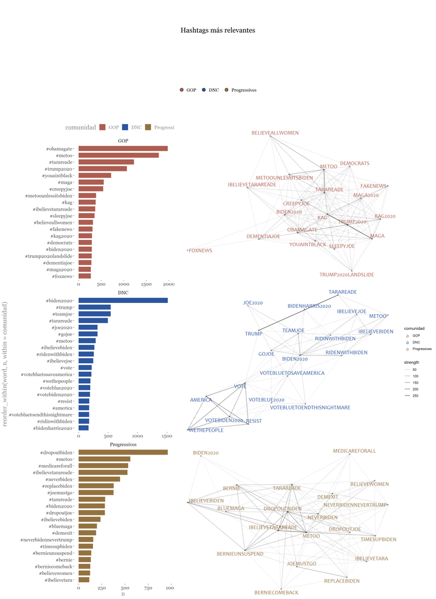

```r
# además de hastgags reivindicativos como #taxtherich# makebillionarespay# pr
plot_topic_networks(biden_frequency, biden_graph, filtered_words = c("#biden", "#joe"),
                    texto_titulo = "Hashtags más relevantes", lab_size = 16, text_size = 5, layout_style = "nicely", minim_n = 3)
```

### Temas propios de comunidades

#### Hashtags

Las connotaciones positivas y negativas en el Bando demócrata y Progresista, respectivamente, se intensifican cuando analizamos los temas propios de cada comunidad. En los demócratas empiezan a aparecer tópicos contra el partido republicano (#moscovmitch, #crookedtrump), mientras que el los progresitas hay hashtags de apoyo al excandidato Bernie Sanders y al partido verde.

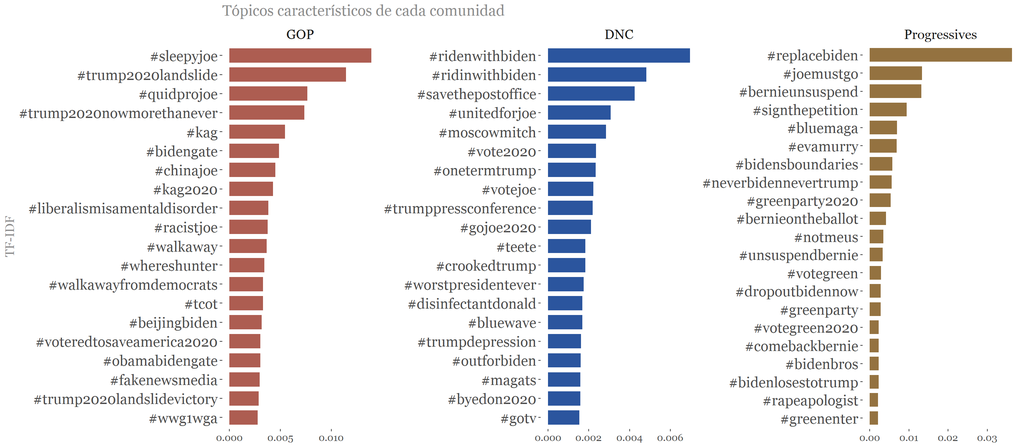

```r
biden_tfidf_hashtags <- get_tfidf(biden_frequency %>% filter(comunidad!= "Independent"))

plot_tfidf(biden_tfidf_hashtags, cols = 3, colores = c(1, 3, 4)) +
  labs(title = "Tópicos característicos de cada comunidad", y = "TF-IDF") +
  guides(fill = F) +
  theme(axis.title.x= element_blank(),
        axis.text.y = element_text(size = 16),
        legend.title = element_blank(),
        strip.text = element_text(size = 15))
```

#### Menciones

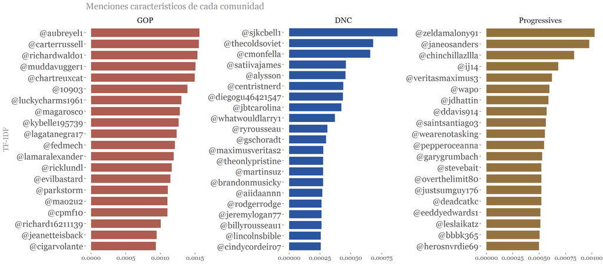

```r
biden_tfidf_mentions <- get_tfidf(biden_unigram %>% filter(str_detect(word, "^@"),comunidad!= "Independent") %>% get_frequencies())

plot_tfidf(biden_tfidf_mentions, cols = 3, colores = c(1, 3, 4)) +
  labs(title = "Menciones característicos de cada comunidad", y = "TF-IDF") +
  guides(fill = F) +
  theme(axis.title.x= element_blank(),
        axis.text.y = element_text(size = 16),
        legend.title = element_blank(),
        strip.text = element_text(size = 15))
```

### SENTIMIENTO: POLARITY

Hay una percepción significativamente positiva por parte de los demócratas hacia Joe Biden, mientras que los progresistas tienen una percepción significativamente negativa.

Hay también una divergencia geográfica en cuanto a la percepción del candidato.

```r
# limpeza de datos: se elimina trump y sanders
biden_for_sent <- biden %>%
  filter(str_detect(text, "#?([Bb]ernie|[Ss]anders|[Dd]onald|[Tt]rump)", negate = T))

# adicion de sentimientos
sent_biden <- sentiment(biden_for_sent$text)

biden_for_sent <- biden_for_sent %>%
  mutate(ave_sentiment = sent_biden$sentiment)

biden_for_sent %>%
  group_by(comunidad) %>%
  summarise(sent = mean(ave_sentiment))
```

```
## # A tibble: 3 x 2
##   comunidad       sent
##   <fct>          <dbl>
## 1 GOP          -0.0497
## 2 DNC           0.0307
## 3 Progressives -0.0229
```

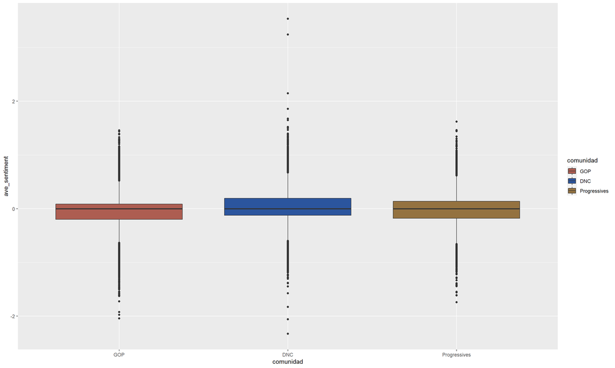

```r
biden_for_sent %>%
  ggplot(aes(x = comunidad, y = ave_sentiment)) +
  geom_boxplot(aes(fill = comunidad)) +
  scale_fill_manual(values = plots_palette[c(1, 3, 4)])
```

```r
# DNC - PRG
test_sent_dnc_prg <- get_test_dif(biden_for_sent, group = c("DNC", "Progressives"))
test_sent_dnc_prg[-1]
```

```
## $IC
##                     2.5%       97.5%
## DNC           0.02818961  0.03312151
## Progressives -0.02548160 -0.02029681
##
## $resultado
## [1] "Diferencia significativa en medias"
```

```r
# DNC - GOP
test_sent_dnc_gop <- get_test_dif(biden_for_sent, group = c("DNC", "GOP"))
test_sent_dnc_gop[-1]
```

```
## $IC
##            2.5%       97.5%
## DNC  0.02820353  0.03314447
## GOP -0.05128617 -0.04816092
##
## $resultado
## [1] "Diferencia significativa en medias"
```

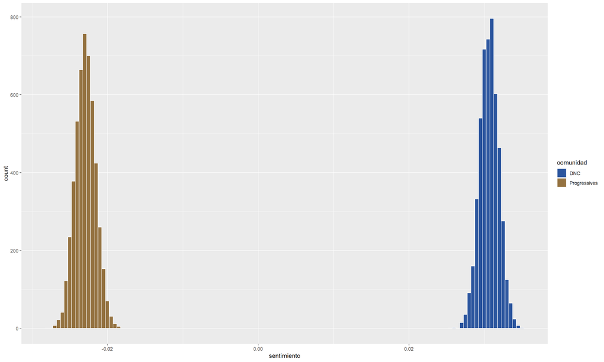

```r
sent_test_data <- bind_rows(test_sent_dnc_prg$data, test_sent_dnc_gop$data)

test_sent_dnc_prg$data %>%
  ggplot(aes(x = sentimiento)) +
  geom_histogram(aes(fill = comunidad), color = "white", binwidth = 0.0005) +
  scale_fill_manual(values = plots_palette[c(3, 4)])
```

```r
# geografia
biden_for_sent <- biden_for_sent %>%
  bind_cols(map_df(.$place_full_name, ~get_state_code(.x)))


biden_sent_states <- biden_for_sent %>%
  filter(comunidad %in% c("DNC", "Progressives")) %>%
  group_by(comunidad, State) %>%
  filter(str_detect(State, "[A-Z]{2}")) %>%
  summarise(sent = mean(ave_sentiment),
            n = n()) %>%
  filter(n > 3)




state_names <- character(length = length(biden_sent_states$State))

for (idx in 1:length(biden_sent_states$State)) {

  state_code <- biden_sent_states$State[idx]

  s_name <- state.name[which(state.abb == state_code)]

  if (length(s_name) == 0)
  {
    print(state_code)
    state_names[idx] <- NA

  } else {


  state_names[idx] <- s_name
  }
}
```

```
## [1] "DC"
## [1] "DC"
```

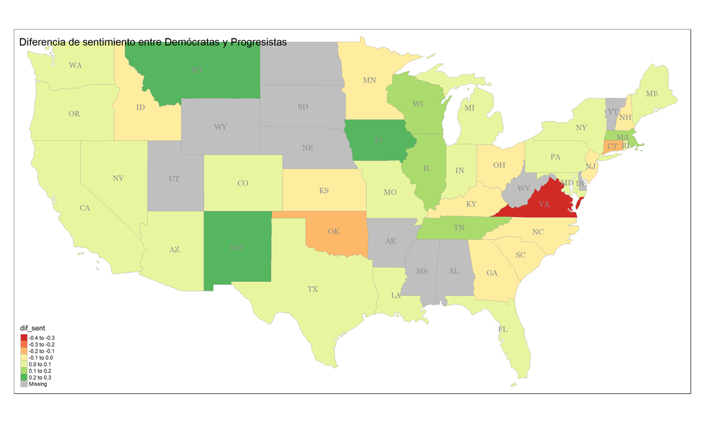

```r
biden_sent_states$state_name <- state_names

biden_sent_states <- biden_sent_states %>%
  filter(!is.na(state_name)) %>%
  select(-n) %>%
  pivot_wider(names_from = comunidad, values_from = sent) %>%
  mutate(dif_sent = DNC - Progressives)

data(us_states)

us_states <- us_states %>%
  left_join(biden_sent_states, by = c("NAME" = "state_name"))

tm_shape(us_states) +
  tm_borders(col = "grey60", lwd = 0.5) +
  tm_fill(col = "dif_sent") +
  tm_text(text = "State", fontfamily = "Georgia", col = "grey55") +
  tm_layout(title = "Diferencia de sentimiento entre Demócratas y Progresistas")
```

#### Sentimiento - NRC

Progresistas y Republicanos están más alineados en su sentimiento que Progresistas y demócratas

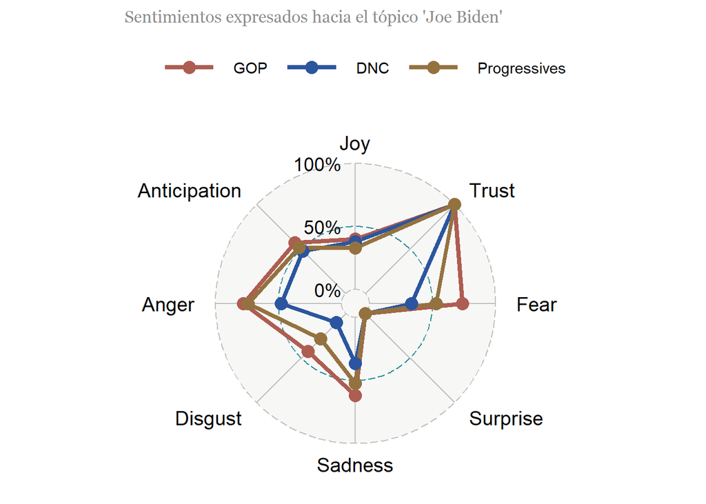

```r
library(scales)
nrc_biden <- biden_for_sent %>%  get_unigrams() %>%
  filter(comunidad!= "Independent") %>%
  inner_join(get_sentiments("nrc"), by = "word") %>%
  filter(!sentiment %in% c("positive", "negative")) %>%
  count(comunidad, sentiment, sort = T) %>%
  mutate(sentiment = str_to_title(sentiment)) %>%
  ungroup() %>%
  group_by(comunidad) %>%
  mutate(n = scales::rescale(n)) %>%
  pivot_wider(names_from = sentiment, values_from = n) %>%
  select(comunidad, Joy, Trust, Fear, Surprise, Sadness, Disgust, Anger, Anticipation)


# el grafico se parece más entre Progresitas y Republicanos que entre demócratas y Republicanos

ggradar(nrc_biden %>% ungroup() %>% mutate(comunidad = fct_drop(comunidad)), group.colours = plots_palette[c(1, 3, 4)], legend.position = "top",
        group.point.size = 4,
        plot.title = "Sentimientos expresados hacia el tópico 'Joe Biden'", legend.text.size = 11) +
  theme(plot.title = element_text(size = 12, family = "Georgia", color = "grey55"),
        axis.title = element_text(family = "Georgia"))
```

### Polarización

Hay una clara polarízación entre demócratas y republicanos. Aunque hay un cierto nivel también entre demócratas y progresistas, este es mucho menor.

```r
# lectura datos test polaridad
pol_test_dif <- readRDS(here::here("datos_procesados", "formated_polarization_df_data", "polarization_testing", "biden_polarization.rds"))

pol_test_dif[-1]
```

```
## $IC
##               2.5%      97.5%
## DNC-GOP 0.22911727 0.23889725
## DNC-PRG 0.01019636 0.01626453
##
## $resultado
## [1] "Diferencia significativa en medias"
```

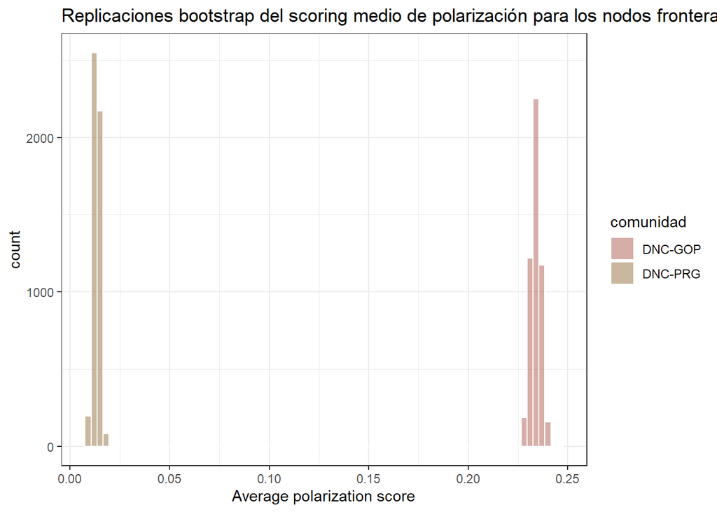

```r
# Nivel de polarizacion mínimo en ambos casos pero se hallan diferencias significativas
pol_test_dif$data %>%
  ggplot(aes(x = sentimiento)) +
  geom_histogram(aes(group = comunidad, fill = comunidad), color = "white", alpha = 0.5, binwidth = 0.003, position = "identity") +
  scale_fill_manual(values = c(plots_palette[1], plots_palette[4])) +
  labs(title = "Replicaciones bootstrap del scoring medio de polarización para los nodos frontera",
       x = "Average polarization score") +
  theme_bw()
```